# DS311 - R Lab Assignment

### Question 3

Download the housing data set from www.jaredlander.com and find out what explains the housing prices in New York City.

Note: Check your working directory to make sure that you can download the data into the data folder.

1. Create your own descriptive statistics and aggregation tables to summarize the data set and find any meaningful results between different variables in the data set.

```r
# Head of the cleaned data set

housingData <-read.csv("housing.csv")

head(housingData)
```

|  | Neighborhood | Building.Classification | Total.Units | Year.Built | Gross.SqFt | Estimated.Gross.Income | Gross.Income.per.SqFt | Estimated.Expense | Expense.per.SqFt | Net.Operating.Income | Full.Market.Value | Market.Value.per.SqFt | Boro |
| --- | --- | --- | --- | --- | --- | --- | --- | --- | --- | --- | --- | --- | --- |
| 1 | FINANCIAL | R9-CONDOMINIUM | 42 | 1920 | 36500 | 1332615 | 36.51 | 342005 | 9.37 | 990610 | 7300000 | 200.00 | Manhattan |
| 2 | FINANCIAL | R4-CONDOMINIUM | 78 | 1985 | 126420 | 6633257 | 52.47 | 1762295 | 13.94 | 4870962 | 30690000 | 242.76 | Manhattan |
| 3 | FINANCIAL | RR-CONDOMINIUM | 500 | NA | 554174 | 17310000 | 31.24 | 3543000 | 6.39 | 13767000 | 90970000 | 164.15 | Manhattan |
| 4 | FINANCIAL | R4-CONDOMINIUM | 282 | 1930 | 249076 | 11776313 | 47.28 | 2784670 | 11.18 | 8991643 | 67556006 | 271.23 | Manhattan |
| 5 | TRIBECA | R4-CONDOMINIUM | 239 | 1985 | 219495 | 10004582 | 45.58 | 2783197 | 12.68 | 7221385 | 54320996 | 247.48 | Manhattan |
| 6 | TRIBECA | R4-CONDOMINIUM | 133 | 1986 | 139719 | 5127687 | 36.70 | 1497788 | 10.72 | 3629899 | 26737996 | 191.37 | Manhattan |

```r
# Enter your code here!
install.packages("dplyr")
library(dplyr)
agg_table <- housingData %>%
  group_by(Boro) %>%
  summarise(
    Avg_Gross_SqFt = mean(Gross.SqFt, na.rm = TRUE),
    Avg_Income = mean(Estimated.Gross.Income, na.rm = TRUE),
    Avg_Expense = mean(Estimated.Expense, na.rm = TRUE),
    Avg_Net_Operating_Income = mean(Net.Operating.Income, na.rm = TRUE),
    Avg_Market_Value = mean(Full.Market.Value, na.rm = TRUE)
  )

print(agg_table)
```

```
## # A tibble: 5 × 6
##   Boro          Avg_Gross_SqFt Avg_Income Avg_Expense Avg_Net_Operating_Income
##   <chr>                  <dbl>      <dbl>       <dbl>                    <dbl>
## 1 Bronx                172666.   2110718.    1137624.                  973094.
## 2 Brooklyn              37946.    736030.     314294.                  421736.
## 3 Manhattan            109186.   4185050.    1232606.                 2952444.
## 4 Queens                58610.   1056390.     437756.                  618634.
## 5 Staten Island         80781.   1066975.     516099.                  550876.
## # ℹ 1 more variable: Avg_Market_Value <dbl>
```

```r
correlations <- cor(housingData[, c("Gross.SqFt", "Estimated.Gross.Income", "Estimated.Expense",
                                     "Net.Operating.Income", "Full.Market.Value")], use = "complete.obs")
print(correlations)
```

```
##                        Gross.SqFt Estimated.Gross.Income Estimated.Expense
## Gross.SqFt              1.0000000              0.8560584         0.9433135
## Estimated.Gross.Income  0.8560584              1.0000000         0.9576951
## Estimated.Expense       0.9433135              0.9576951         1.0000000
## Net.Operating.Income    0.7945727              0.9918870         0.9133413
## Full.Market.Value       0.7747158              0.9829985         0.8982289
##                        Net.Operating.Income Full.Market.Value
## Gross.SqFt                        0.7945727         0.7747158
## Estimated.Gross.Income            0.9918870         0.9829985
## Estimated.Expense                 0.9133413         0.8982289
## Net.Operating.Income              1.0000000         0.9940990
## Full.Market.Value                 0.9940990         1.0000000
```

2. Create multiple plots to demonstrates the correlations between different variables. Remember to label all axes and give title to each graph.

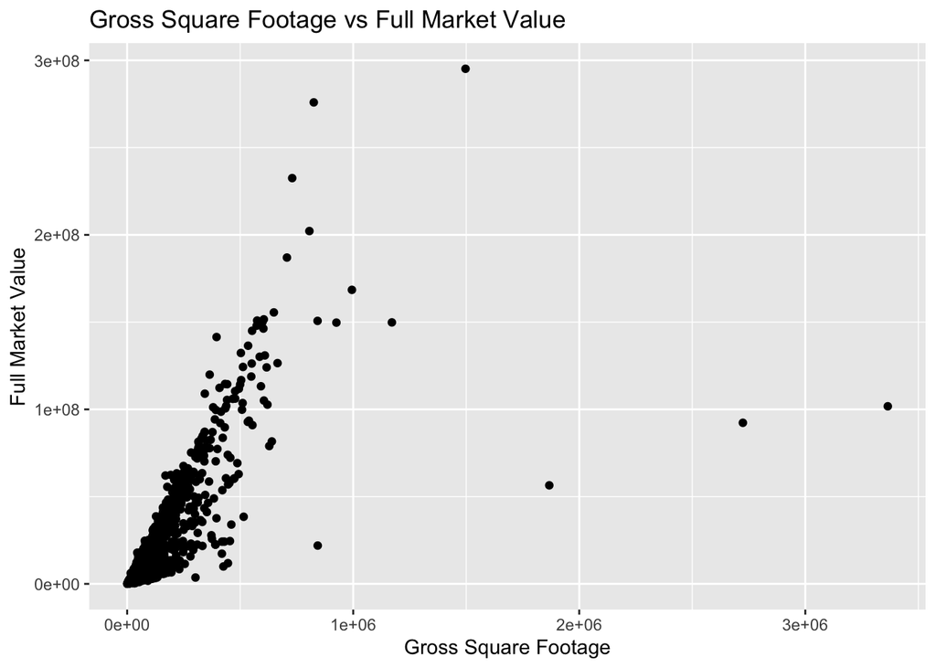

```r
# Enter your code here!
install.packages("ggplot2")
library(ggplot2)
ggplot(housingData, aes(x = Gross.SqFt, y = Full.Market.Value)) +
  geom_point() +
  labs(title = "Gross Square Footage vs Full Market Value",
       x = "Gross Square Footage",
       y = "Full Market Value")
```

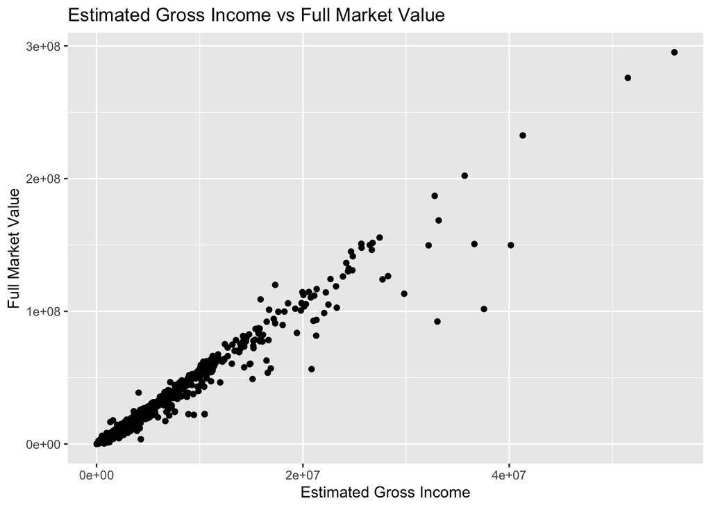

```r
ggplot(housingData, aes(x = Estimated.Gross.Income, y = Full.Market.Value)) +
  geom_point() +
  labs(title = "Estimated Gross Income vs Full Market Value",
       x = "Estimated Gross Income",
       y = "Full Market Value")
```

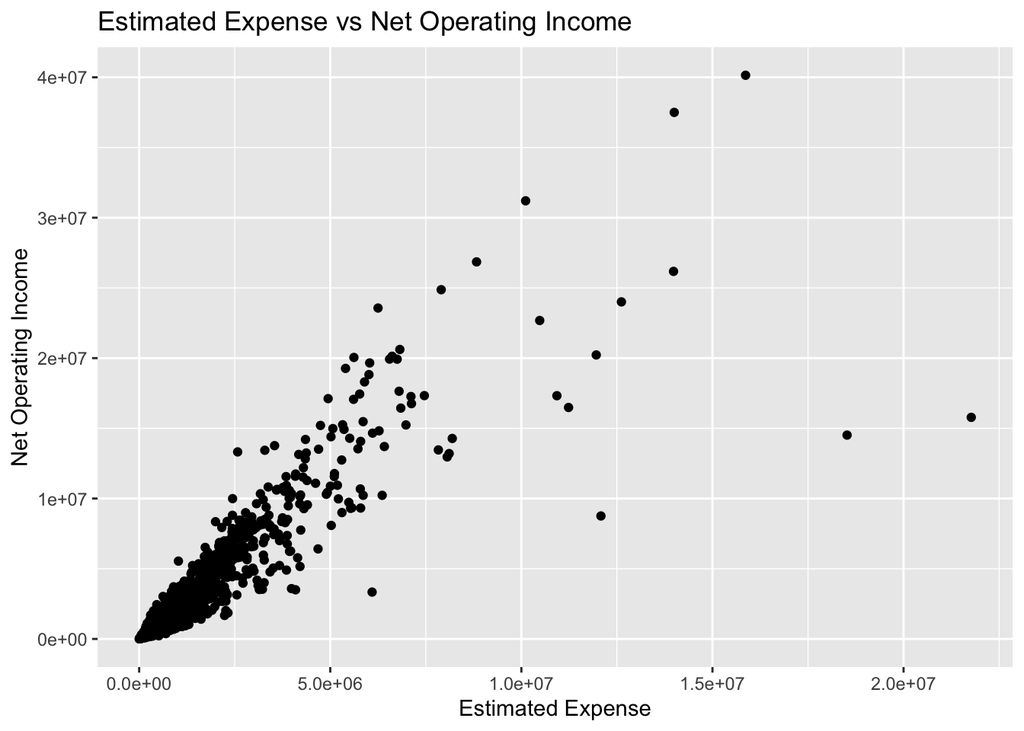

```r
ggplot(housingData, aes(x = Estimated.Expense, y = Net.Operating.Income)) +
  geom_point() +
  labs(title = "Estimated Expense vs Net Operating Income",
       x = "Estimated Expense",
       y = "Net Operating Income")
```

3. Write a summary about your findings from this exercise.